# Travel_insurance_case_study (1)

[figure not shown]

## Travel insurance case study

### Introduction to Python

#### 22/08/2020

# Agenda of this Case Study

Derive insights from the data, in doing so we will

- learn to use python to fetch, manipulate, see and understand data
- get familiar with some common python libraries and functions we use for EDA

# Context

An insurance claim is a formal request by a policyholder to an insurance company for coverage or compensation for a covered loss or policy event. The insurance company validates the claim and, once approved, issues payment to the insured or an approved interested party on behalf of the insured.

In many cases, third-parties file claims on behalf of the insured person, but usually, only the person(s) listed on the policy is entitled to claim payments. [source](https://www.investopedia.com/terms/i/insurance_claim.asp)

# Data

This data is from a third-party travel insurance servicing company that is based in Singapore. [source](https://www.kaggle.com/mhdzahier/travel-insurance)

The attributes:

- Target: Claim Status (Claim.Status)
- Name of agency (Agency)
- Type of travel insurance agencies (Agency.Type)
- Distribution channel of travel insurance agencies (Distribution.Channel)
- Name of the travel insurance products (Product.Name)
- Duration of travel (Duration)
- Destination of travel (Destination)
- Amount of sales of travel insurance policies (Net.Sales)
- Commission received for travel insurance agency (Commission)
- Gender of insured (Gender)
- Age of insured (Age)

# Approach

#### Step 1: Import necessary libraries and data

#### Step 2: Exploring the dataset as a whole

#### Step 3: Univariate Analysis

#### Step 4: Bivariate Analysis

#### Step 5: Conclusion

# Import necessary libraries and data

```python
%matplotlib inline
#to disply the plots as part of the notebook
import pandas as pd    # primariy to handle dataframes
import numpy as np     # for arithmatic operations on vectors
import matplotlib.pyplot as plt   # visualization library
```

```python
df = pd.read_csv('travel insurance.csv')
print(df.shape)
df.head()
```

```
(63326, 11)
```

|  | Agency | Agency Type | Distribution Channel | Product Name | Claim | Duration | Destination | Net Sales | Commision (in value) | Gender | Age |
| --- | --- | --- | --- | --- | --- | --- | --- | --- | --- | --- | --- |
| 0 | CBH | Travel Agency | Offline | Comprehensive Plan | No | 186 | MALAYSIA | -29.0 | 9.57 | F | 81 |
| 1 | CBH | Travel Agency | Offline | Comprehensive Plan | No | 186 | MALAYSIA | -29.0 | 9.57 | F | 71 |
| 2 | CWT | Travel Agency | Online | Rental Vehicle Excess Insurance | No | 65 | AUSTRALIA | -49.5 | 29.70 | NaN | 32 |
| 3 | CWT | Travel Agency | Online | Rental Vehicle Excess Insurance | No | 60 | AUSTRALIA | -39.6 | 23.76 | NaN | 32 |
| 4 | CWT | Travel Agency | Online | Rental Vehicle Excess Insurance | No | 79 | ITALY | -19.8 | 11.88 | NaN | 41 |

- The head of the data gives us a good idea of what the data looks like
- In this case, we can see there are 11 columns and 63326 rows of data
- There are a bunch of categorical columns and few numerical ones
- And we also see there are missing values in the data

# Exploring the dataset as a whole

```python
df.info()
```

```
<class 'pandas.core.frame.DataFrame'>
RangeIndex: 63326 entries, 0 to 63325
Data columns (total 11 columns):
 #   Column                Non-Null Count  Dtype
---  ------                --------------  -----
 0   Agency                63326 non-null  object
 1   Agency Type           63326 non-null  object
 2   Distribution Channel  63326 non-null  object
 3   Product Name          63326 non-null  object
 4   Claim                 63326 non-null  object
 5   Duration              63326 non-null  int64
 6   Destination           63326 non-null  object
 7   Net Sales             63326 non-null  float64
 8   Commision (in value)  63326 non-null  float64
 9   Gender                18219 non-null  object
 10  Age                   63326 non-null  int64
dtypes: float64(2), int64(2), object(7)
memory usage: 5.3+ MB
```

- Looking at the head gives us some idea, but the info() method gives a more elaborate picture
- We see there are missing values only in the Gender column, 4 numeric columns and 7 columns with strings
- Since there are a lot of categorical columns, we can see how many categories each one has

```python
#iterate through a list of columns and print the number of unique values in each of them

for i in ['Agency', 'Agency Type', 'Distribution Channel', 'Product Name','Claim','Destination', 'Gender']:
    print(f'{i} {len(df[i].unique())}')    # f-strings are a way to perform string formatting in python
```

```
Agency 16
Agency Type 2
Distribution Channel 2
Product Name 26
Claim 2
Destination 149
Gender 3
```

- These are the number of categories that we have in each of the categories
- Notice we have 3 categories in Gender. That is because it considers the NaN value also as a unique entry in the column
- From now on, we will explore one column after the other and later compare the columns with each other and eventualy get to some valuable insights

# Univariate analysis

## Categorical data

```python
df.Agency.value_counts()  # gives the number of entries of every unique value in the series
```

```
EPX    35119
CWT     8580
C2B     8267
JZI     6329
SSI     1056
JWT      749
RAB      725
LWC      689
TST      528
KML      392
ART      331
CCR      194
CBH      101
TTW       98
CSR       86
ADM       82
Name: Agency, dtype: int64
```

- We can plot the above data instead since ther are quiet a few categories

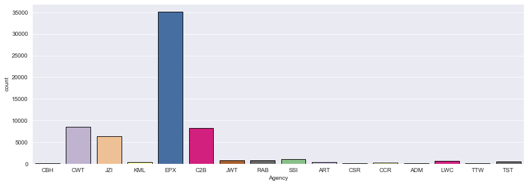

```python
import seaborn as sns   # a higher level library for viz (aka prettier charts)

sns.set_style(style='darkgrid')
plt.figure(figsize = (15,5))
sns.countplot(df.Agency, edgecolor = 'black', palette = 'Accent')
plt.show()
```

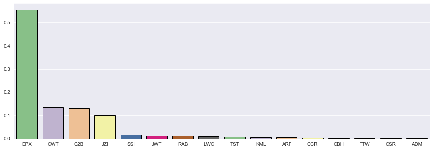

```python
plt.figure(figsize = (15,5))
series = df.Agency.value_counts(normalize = True)
sns.barplot(series.index, series.values, edgecolor = 'black', palette = 'Accent')
plt.show()
```

- Now we can see that about 55% of the data is of EPX, CWT and C2B individually have a share of about 13% and JZI has a share of 10%
- Together, the top 4 constitute about 90% of the data

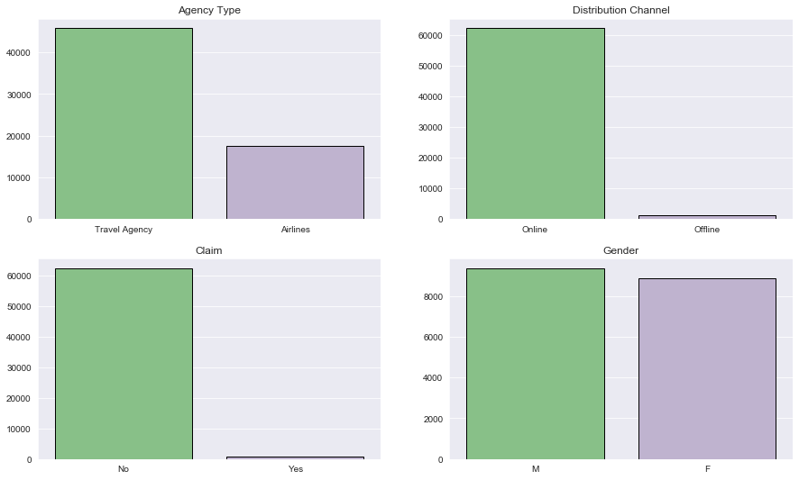

```python
# we can plot more than one plot at once.
# Let's plot all the attributes with 2 categories
# there are 4 variables to plot hence, we will require a 2X2 grid

# initialized a variable 'position' to go over every position on the grid to plot

position = 1
plt.figure(figsize=(15,9))

for column in ['Agency Type', 'Distribution Channel', 'Claim', 'Gender']:

    plt.subplot(2,2,position)

    series = df[column].value_counts()

    sns.barplot(series.index, series.values, edgecolor = 'black', palette = 'Accent')

    plt.title(column)

    position += 1

plt.show()
```

- We can see the distribution of each one of the 4 attributes. Notice that the plot ignores the NaN values
- The Agency type column is quiet skewed with the majority of them being Travel Agency type and about 25% of are Airlines
- Offline bookings are miniscule compared to online bookings
- There are far more unclaimed insurance packages than there are claimed ones, which is expected
- The gender ratio of the travellers looks pretty balanced

*task for you: find out which is the most and least popular Insurance product among the customers*

### Plotting a map

Since we got countries in the data, instead of plotting a bar chart to get an idea of the frequencies we can plot a map. Challenge here is that instead of names of the countries, we need the country codes for the plotly library to recognise which value belongs to which country in the map and color or represent the number as circles accordingly.

For that, we have a list of all the country codes, and we have to assign these country codes to countries in the main dataframe. But, there are differences in the way countries are written. In the main dataframe, we have "United States" and in the codes data, we have "United States of America". Similarly there are other countries that are written differently in the two dataframes.

```python
# We have column with names of countries. We can plot a map and have the color indicate the frequency of a given country
# We can use plotly for this purpose
# one challenge is that we need to provide the ISO codes of all the countries for the library(plotly) to draw them on the map

codes = pd.read_csv('country_codes.csv', usecols  = ['name', 'alpha-3'])  # we just want the 3 letter code for each country
codes.head()
```

|  | name | alpha-3 |
| --- | --- | --- |
| 0 | Afghanistan | AFG |
| 1 | Åland Islands | ALA |
| 2 | Albania | ALB |
| 3 | Algeria | DZA |
| 4 | American Samoa | ASM |

```python
countries = pd.DataFrame({'country': df.Destination.value_counts().index,
                         'count' : df.Destination.value_counts().values})
countries['code'] = pd.Series(dtype = object)
```

```python
# In a single overall iteration, one element from codes, gets compared with every element from countries.
# If the match ratio is more tahn 80, we consider both the elements to mean the same thing
# We assign the respective alpha code from codes against the respective country name

from fuzzywuzzy import fuzz    # a library function that helps perform a fuzzy match  !pip install fuzzywuzzy

for i in codes.index:
    for j in countries.index:
        ratio = fuzz.ratio(str.lower(codes.loc[i,'name']), str.lower(countries.loc[j, 'country']))
        if ratio > 90:
            countries.loc[j, 'code'] = codes.loc[i, 'alpha-3']
```

```python
# countries.sample(10)
```

```python
countries[countries.code.isna()]   # strings that did not have a partial match
```

|  | country | count | code |
| --- | --- | --- | --- |
| 6 | UNITED STATES | 2530 | NaN |
| 13 | UNITED KINGDOM | 1309 | NaN |
| 44 | CZECH REPUBLIC | 69 | NaN |
| 78 | BOLIVIA | 10 | NaN |
| 96 | VENEZUELA | 5 | NaN |
| 103 | MACEDONIA, THE FORMER YUGOSLAV REPUBLIC OF | 3 | NaN |
| 115 | REUNION | 2 | NaN |
| 137 | LIBYAN ARAB JAMAHIRIYA | 1 | NaN |
| 141 | TIBET | 1 | NaN |
| 143 | REPUBLIC OF MONTENEGRO | 1 | NaN |

```python
manual_codes = ['USA', 'GBR','CZE','BOL', 'VEN', 'FRA', 'YUG', 'LBY', 'CHN', 'MNE']

countries.loc[countries[countries.code.isna()].index, 'code'] = manual_codes
```

```python
countries
```

|  | country | count | code |
| --- | --- | --- | --- |
| 0 | SINGAPORE | 13255 | SGP |
| 1 | MALAYSIA | 5930 | MYS |
| 2 | THAILAND | 5894 | THA |
| 3 | CHINA | 4796 | CHN |
| 4 | AUSTRALIA | 3694 | AUS |
| ... | ... | ... | ... |
| 144 | RWANDA | 1 | RWA |
| 145 | SOLOMON ISLANDS | 1 | SLB |
| 146 | GUINEA-BISSAU | 1 | GNB |
| 147 | SIERRA LEONE | 1 | SLE |
| 148 | ARMENIA | 1 | ARM |

149 rows × 3 columns

```python
import plotly.express as px



fig = px.scatter_geo(countries, locations="code",
                     hover_name="country", size="count",
                     projection="natural earth",
                    size_max=50)

fig.update_layout({ 'geo': {'resolution': 50}})   # to increase the resolution for the smaller ountries to show up on the map


fig.show()
```

[interactive chart not shown]

```python
fig = px.choropleth(countries, locations="code",
                    color="count",
                    hover_name="country",
                    color_continuous_scale=px.colors.sequential.algae,
                   projection = 'natural earth')
fig.show()
```

[interactive chart not shown]

- Now it is much easier to draw some conclusions about the data
- Most of the data is coming from the south east Asia and Australia
- Travelling activity in Singapore is disproportionately huge

Note: Since we had to match data from a different source with slightly different string values, we had to perform slightly complicated operation. Although there can be better ways of doing the same

## Continuous data

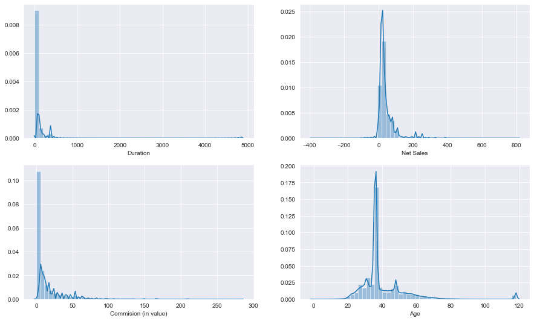

```python
position = 1
plt.figure(figsize=(15,9))

for column in ['Duration', 'Net Sales', 'Commision (in value)', 'Age']:

    plt.subplot(2,2,position)

    sns.distplot(df[column] )

    position += 1

plt.show()
```

- The first three distributions are heavily right skewed and the Age column resembels a Normal distribution
- We can look at the boxplots to get an even better idea about the distribution and the outliers but, it is beyond the scope for now
- Now that we have looked into the individual distributions, we can start comparing one column with the other

# Bi-variate Analysis

When we have to compare to variables, we generally come across any of the following situations

**categorical vs categorical** . .options: crosstab, stacked bar chart etc

**categorical vs continuous** . .options: multiple boxplot, multiple histogram etc

**continuous vs continuous** . .options: scatterplot, line chart etc

Let's answer 3 questions to address each scenario

What is the nature of relation between,

```
a) Gender and Claim?
b) Claim and Age?
c) Commision and Duration?
```

#### a) Relation between two categorical variables - Gender and Claim

```python
pd.crosstab(df.Claim, df.Gender, normalize= 'index', margins = True)
```

| Gender Claim | F | M |
| --- | --- | --- |
| No | 0.484983 | 0.515017 |
| Yes | 0.541471 | 0.458529 |
| All | 0.486964 | 0.513036 |

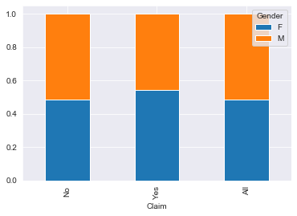

```python
pd.crosstab(df.Claim, df.Gender, normalize= 'index', margins=True).plot.bar(stacked = True)
plt.show()
```

#### b) Relation between one categorical and one continuous variable - Claim and Age

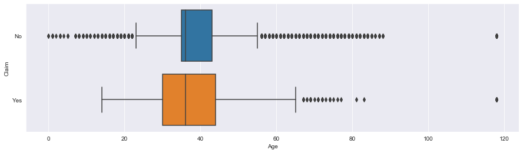

```python
plt.figure(figsize=(15,4))
sns.boxplot(data = df, y = 'Claim', x = 'Age')
plt.show()
```

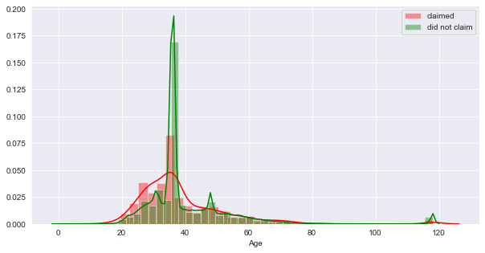

```python
plt.figure(figsize=(10,5))
sns.distplot(df.Age[df.Claim == 'Yes'], color = 'Red')
sns.distplot(df.Age[df.Claim == 'No'], color = 'Green')
plt.legend(['claimed', 'did not claim'])
plt.show()
```

- Notice the way the boxplot and histogram agree with eachother
- Although the median is about the same and evern the distributions are quiet identical, there is a difference between them at the lower extrem values. Likely because minors claiming for insurance is quiet rare

#### c) Relation between two continuous variables - Commision, Duration

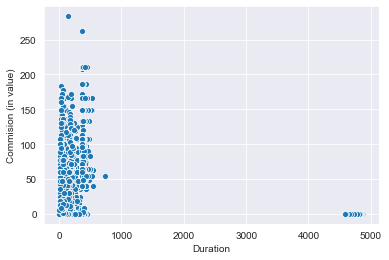

```python
sns.scatterplot( df.Duration, df['Commision (in value)'])
plt.show()
```

- My presumption that longer flights probably fetch more commision turns out to be false
- Flight duration has no affect on the commissions the agency or airlines make, with a few exceptions

# Conclusion

- We have seen how to understand the meta-data
- We explored ways to derive insights from continuous, categorical and even geographical data
- We have dealt with a problem where we could not match the strings easily to join two datasets, so we plugged in a function which can perform partial match. Still, there were issues with certain countries where we manually encoded the country codes
- You can further explore this dataset, make some assumptions and try to prove or disprove using visual and some basic numerical analysis, like we have done in the end with a simpe scatterplot

[figure not shown]

```
 ©Great Learning. Proprietary content. All Rights Reserved. Unauthorised use or distribution prohibited
```